# chapter5

# Reading the data

```r
setwd("C:/Users/Sara Allaouat/Documents/IODS-project/data")
human <- read.table("human2.txt", header = TRUE, sep = "")
str(human)
```

```
## 'data.frame':    155 obs. of  8 variables:
##  $ edu         : num  1.007 0.997 0.983 0.989 0.969 ...
##  $ work_f      : num  61.2 58.8 61.8 58.7 58.5 53.6 53.1 56.3 61.6 62 ...
##  $ health_birth: num  81.6 82.4 83 80.2 81.6 80.9 80.9 79.1 82 81.8 ...
##  $ edu_exp     : num  17.5 20.2 15.8 18.7 17.9 16.5 18.6 16.5 15.9 19.2 ...
##  $ GNI         : int  166 135 156 139 140 137 127 154 134 117 ...
##  $ MMR         : int  4 6 6 5 6 7 9 28 11 8 ...
##  $ ABR         : num  7.8 12.1 1.9 5.1 6.2 3.8 8.2 31 14.5 25.3 ...
##  $ parliament  : num  39.6 30.5 28.5 38 36.9 36.9 19.9 19.4 28.2 31.4 ...
```

```r
colnames(human)
```

```
## [1] "edu"          "work_f"       "health_birth" "edu_exp"
## [5] "GNI"          "MMR"          "ABR"          "parliament"
```

# Graphical overview of the data

```r
install.packages("ggplot2")
install.packages("GGally")
```

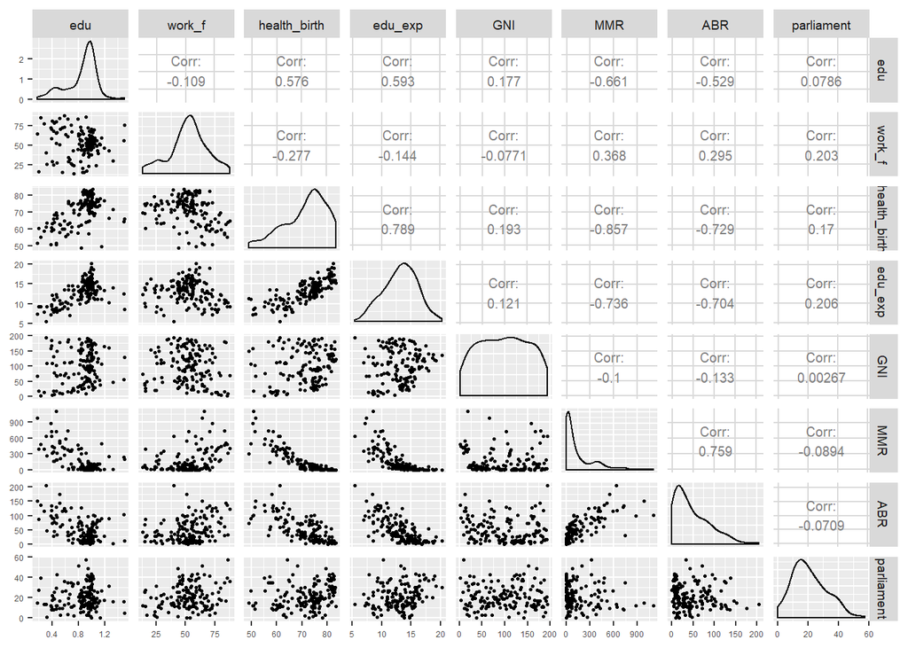

```r
library(ggplot2)
library(GGally)
p <- ggpairs(human, upper=list(continuous=wrap("cor",size=2.7)), lower=list(continuous=wrap("points",size=0.5)))
p <- p + theme(axis.text=element_text(size=4.5),strip.text=element_text(size=7))
p
```

```r
summary(human)
```

```
##       edu             work_f       health_birth      edu_exp
##  Min.   :0.1717   Min.   :13.50   Min.   :49.00   Min.   : 5.40
##  1st Qu.:0.7264   1st Qu.:44.45   1st Qu.:66.30   1st Qu.:11.25
##  Median :0.9375   Median :53.50   Median :74.20   Median :13.50
##  Mean   :0.8529   Mean   :52.52   Mean   :71.65   Mean   :13.18
##  3rd Qu.:0.9968   3rd Qu.:61.90   3rd Qu.:77.25   3rd Qu.:15.20
##  Max.   :1.4967   Max.   :88.10   Max.   :83.50   Max.   :20.20
##       GNI              MMR              ABR           parliament
##  Min.   :  2.00   Min.   :   1.0   Min.   :  0.60   Min.   : 0.00
##  1st Qu.: 53.50   1st Qu.:  11.5   1st Qu.: 12.65   1st Qu.:12.40
##  Median : 99.00   Median :  49.0   Median : 33.60   Median :19.30
##  Mean   : 98.73   Mean   : 149.1   Mean   : 47.16   Mean   :20.91
##  3rd Qu.:143.50   3rd Qu.: 190.0   3rd Qu.: 71.95   3rd Qu.:27.95
##  Max.   :194.00   Max.   :1100.0   Max.   :204.80   Max.   :57.50
```

## Variable distribution

“edu” and “work_f” are bimodal skewed to the left.  
“health_birth” is skewed to the left.  
“edu_exp” is more or less a normal distribution slightly skewed to the left.  
“GNI” tends to a flat distribution except for countries with lowest and highest GNI.  
“MMR” is bimodal skewed to the right.  
“ABR” and “parliament” are skewed to the right.

## Relationships between variables

The strongest positive correlations are observed between:  
- edu_exp and health_birth (0.789).  
- ABR and MMR (0.759).

The strongest negative correlations are observed between:  
- MMR and health_birth (-0.857).  
- MMR and edu_exp (-0.736).  
- ABR and health_birth (-0.729).  
- ABR and edu_exp (-0.704).

# Principal component analysis (PCA)

```r
pca_human <- prcomp(human)
pca_human
```

```
## Standard deviations (1, .., p=8):
## [1] 214.4023406  54.4894547  26.3824261  15.4844500  10.6733370   4.0591640
## [7]   1.5828403   0.1718067
##
## Rotation (n x k) = (8 x 8):
##                        PC1           PC2           PC3          PC4
## edu          -0.0007462386 -0.0004682729 -0.0001602746  0.002208594
## work_f        0.0277430837  0.0118893308  0.0106934445  0.925631580
## health_birth -0.0334324186 -0.0156971133 -0.0302656911  0.041682525
## edu_exp      -0.0098035804 -0.0024142120 -0.0222226664  0.031948985
## GNI          -0.0278267914 -0.9978596062  0.0559348083  0.011116323
## MMR           0.9876013458 -0.0365484292 -0.1476988503 -0.020494484
## ABR           0.1478588893  0.0504360947  0.9866755951 -0.011034526
## parliament   -0.0047883109  0.0016779892 -0.0018391409  0.373868656
##                       PC5          PC6          PC7           PC8
## edu          -0.001350281 -0.000893019 -0.022148446 -9.997505e-01
## work_f       -0.376147482 -0.018132659  0.018988815  2.120414e-03
## health_birth  0.061346323  0.977248937  0.192814892 -5.098149e-03
## edu_exp       0.018652657  0.189982589 -0.980548391  2.161074e-02
## GNI          -0.003969757 -0.015235942 -0.001185831  5.489901e-04
## MMR           0.015599965  0.028763095 -0.001251626 -7.606817e-04
## ABR           0.010661110  0.039477513 -0.016471950 -1.287530e-06
## parliament    0.924135909 -0.077094860  0.014894414 -6.802475e-04
```

```r
summary(pca_human)
```

```
## Importance of components:
##                             PC1      PC2      PC3      PC4      PC5
## Standard deviation     214.4023 54.48945 26.38243 15.48445 10.67334
## Proportion of Variance   0.9193  0.05937  0.01392  0.00479  0.00228
## Cumulative Proportion    0.9193  0.97863  0.99255  0.99734  0.99962
##                            PC6     PC7    PC8
## Standard deviation     4.05916 1.58284 0.1718
## Proportion of Variance 0.00033 0.00005 0.0000
## Cumulative Proportion  0.99995 1.00000 1.0000
```

Every principal component (PC) is dominated by one variable. For example, PC1 is largely dominated by variable MMR. PC2 is largely dominated by the variable GNI. PC3 by ABR… Also, PC1 alone explains 91.93% of the total variance of the observed variables.

# Biplot PC1xPC2

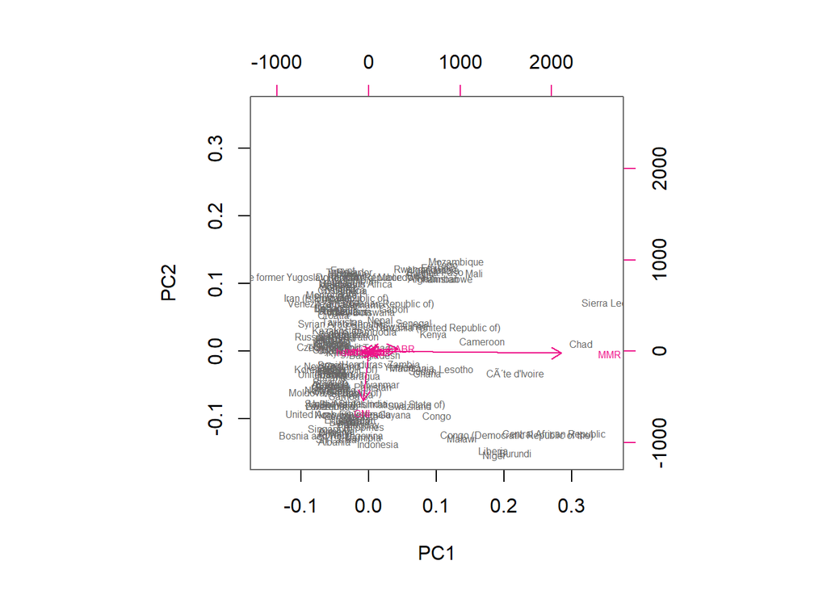

```r
biplot(pca_human, choices = 1:2, cex= c(0.5, 0.5), col = c("grey40", "deeppink2"))
```

Here we can see that MMR is strongly and positively correlated with PC1 (arrows almost parallel) and GNI is strongly and negatively correlated with PC2. The arrow of MMR is long which means that it has a large standard deviation. This can be easily verified from the PCA results table above.

# Scaling the variables

```r
human_sc <- scale(human)
summary(human_sc)
```

```
##       edu              work_f          health_birth        edu_exp
##  Min.   :-2.8189   Min.   :-2.43186   Min.   :-2.7188   Min.   :-2.7378
##  1st Qu.:-0.5233   1st Qu.:-0.50289   1st Qu.:-0.6425   1st Qu.:-0.6782
##  Median : 0.3503   Median : 0.06116   Median : 0.3056   Median : 0.1140
##  Mean   : 0.0000   Mean   : 0.00000   Mean   : 0.0000   Mean   : 0.0000
##  3rd Qu.: 0.5958   3rd Qu.: 0.58469   3rd Qu.: 0.6717   3rd Qu.: 0.7126
##  Max.   : 2.6646   Max.   : 2.21762   Max.   : 1.4218   Max.   : 2.4730
##       GNI                 MMR               ABR            parliament
##  Min.   :-1.767729   Min.   :-0.6992   Min.   :-1.1325   Min.   :-1.8203
##  1st Qu.:-0.826563   1st Qu.:-0.6496   1st Qu.:-0.8394   1st Qu.:-0.7409
##  Median : 0.004952   Median :-0.4726   Median :-0.3298   Median :-0.1403
##  Mean   : 0.000000   Mean   : 0.0000   Mean   : 0.0000   Mean   : 0.0000
##  3rd Qu.: 0.818192   3rd Qu.: 0.1932   3rd Qu.: 0.6030   3rd Qu.: 0.6127
##  Max.   : 1.741082   Max.   : 4.4899   Max.   : 3.8344   Max.   : 3.1850
```

```r
class(human_sc)
```

```
## [1] "matrix"
```

```r
human_sc <- as.data.frame(human_sc)
class(human_sc)
```

```
## [1] "data.frame"
```

Now all the variables are standardised into one scale.

# PCA with the scaled variables

```r
pca_human_sc <- prcomp(human_sc)
pca_human_sc
```

```
## Standard deviations (1, .., p=8):
## [1] 1.9868715 1.1100007 0.9870561 0.8570172 0.6866880 0.5393924 0.4891390
## [8] 0.3312709
##
## Rotation (n x k) = (8 x 8):
##                      PC1         PC2          PC3          PC4         PC5
## edu          -0.37578754  0.08272706 -0.085325216  0.417736962 -0.78114189
## work_f        0.17768459  0.64919994 -0.104860543  0.631411968  0.29544311
## health_birth -0.46165444  0.03861332  0.011105601 -0.056198759  0.22260286
## edu_exp      -0.43755936  0.16546050  0.059895963  0.086315712  0.25330952
## GNI          -0.11090857 -0.08545836 -0.978095157 -0.092853090  0.08106637
## MMR           0.46706226  0.06540635 -0.122701085 -0.000768639  0.04051532
## ABR           0.43108217  0.05530922 -0.078800940 -0.009724305 -0.36916778
## parliament   -0.07968181  0.72676494 -0.008816656 -0.638348811 -0.21051099
##                       PC6          PC7         PC8
## edu           0.135667249  0.095816841  0.17996187
## work_f        0.027631338 -0.210931914 -0.06890884
## health_birth -0.409985887 -0.394578284  0.63935129
## edu_exp      -0.359619650  0.736877759 -0.18342810
## GNI           0.007054914 -0.003622457 -0.09203083
## MMR           0.124547607  0.495555451  0.70695820
## ABR          -0.809130093 -0.044017710 -0.10904582
## parliament    0.114729248 -0.010959942 -0.01728564
```

```r
s <- summary(pca_human_sc)
s
```

```
## Importance of components:
##                           PC1    PC2    PC3     PC4     PC5     PC6
## Standard deviation     1.9869 1.1100 0.9871 0.85702 0.68669 0.53939
## Proportion of Variance 0.4935 0.1540 0.1218 0.09181 0.05894 0.03637
## Cumulative Proportion  0.4935 0.6475 0.7692 0.86106 0.92001 0.95638
##                            PC7     PC8
## Standard deviation     0.48914 0.33127
## Proportion of Variance 0.02991 0.01372
## Cumulative Proportion  0.98628 1.00000
```

```r
pca_pr <- round(100*s$importance[2, ], digits = 1)
pca_pr
```

```
##  PC1  PC2  PC3  PC4  PC5  PC6  PC7  PC8
## 49.3 15.4 12.2  9.2  5.9  3.6  3.0  1.4
```

Most of the PCs have a more moderate-sized coefficients on several of the variables, except PC3 which is clearly dominated by GNI only.  
The five first PCs explain 92% of the variations in the observations.  
When the variables are on the same scale, there is a more accurate estimation of the principal components and their explanatory variables.

# Biplot with the scaled variables PC1xPC2

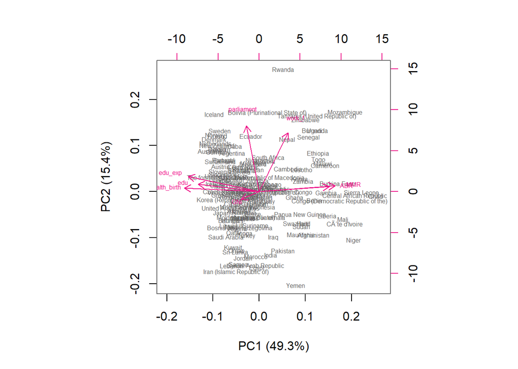

```r
pc_lab <- paste0(names(pca_pr), " (", pca_pr, "%)")
biplot(pca_human_sc, cex = c(0.5, 0.5), col = c("grey40", "deeppink2"), xlab = pc_lab[1], ylab = pc_lab[2])
```

# Loading and exploring tea dataset

```r
install.packages("FactoMineR")

install.packages("dplyr")

install.packages("tidyr")
```

```r
library(FactoMineR)
library(ggplot2)
library(GGally)
library(dplyr)
library(tidyr)
data(tea)
str(tea)
```

```
## 'data.frame':    300 obs. of  36 variables:
##  $ breakfast       : Factor w/ 2 levels "breakfast","Not.breakfast": 1 1 2 2 1 2 1 2 1 1 ...
##  $ tea.time        : Factor w/ 2 levels "Not.tea time",..: 1 1 2 1 1 1 2 2 2 1 ...
##  $ evening         : Factor w/ 2 levels "evening","Not.evening": 2 2 1 2 1 2 2 1 2 1 ...
##  $ lunch           : Factor w/ 2 levels "lunch","Not.lunch": 2 2 2 2 2 2 2 2 2 2 ...
##  $ dinner          : Factor w/ 2 levels "dinner","Not.dinner": 2 2 1 1 2 1 2 2 2 2 ...
##  $ always          : Factor w/ 2 levels "always","Not.always": 2 2 2 2 1 2 2 2 2 2 ...
##  $ home            : Factor w/ 2 levels "home","Not.home": 1 1 1 1 1 1 1 1 1 1 ...
##  $ work            : Factor w/ 2 levels "Not.work","work": 1 1 2 1 1 1 1 1 1 1 ...
##  $ tearoom         : Factor w/ 2 levels "Not.tearoom",..: 1 1 1 1 1 1 1 1 1 2 ...
##  $ friends         : Factor w/ 2 levels "friends","Not.friends": 2 2 1 2 2 2 1 2 2 2 ...
##  $ resto           : Factor w/ 2 levels "Not.resto","resto": 1 1 2 1 1 1 1 1 1 1 ...
##  $ pub             : Factor w/ 2 levels "Not.pub","pub": 1 1 1 1 1 1 1 1 1 1 ...
##  $ Tea             : Factor w/ 3 levels "black","Earl Grey",..: 1 1 2 2 2 2 2 1 2 1 ...
##  $ How             : Factor w/ 4 levels "alone","lemon",..: 1 3 1 1 1 1 1 3 3 1 ...
```

[output cut: 22 more lines]

```r
dim(tea)
```

```
## [1] 300  36
```

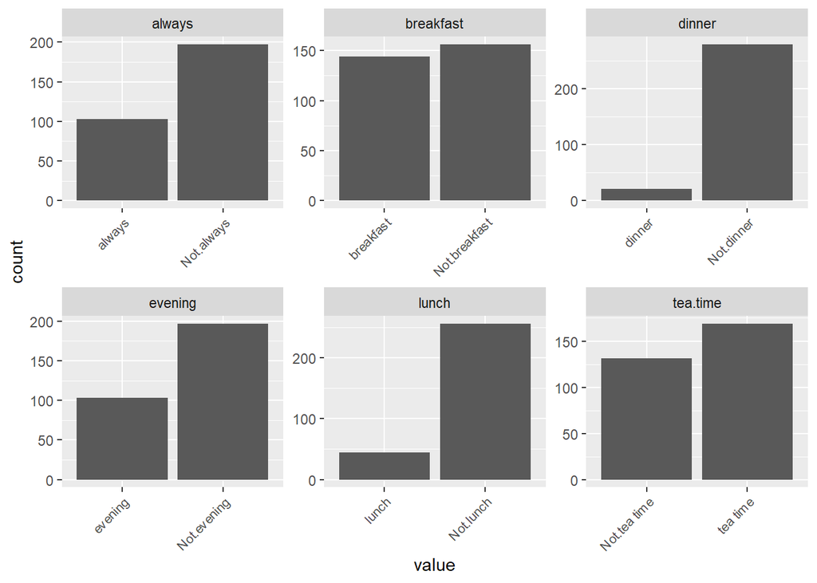

```r
tea_time <- tea[,1:6]
gather(tea_time) %>% ggplot(aes(value))+ geom_bar() + facet_wrap("key", scales = "free") + theme(axis.text.x = element_text(angle = 45, hjust = 1, size = 8))
```

The dataset tea has 300 observations of 36 variables related to the time, frequency, place, and how tea is consumed. Also variables describing the health status of the participants and why they consume tea. The visualization of the first 6 variables of the dataset shows that most responders take tea out of dinner and lunch time. Most of the time not in evenings.

# Multiple Correspondence Analysis (MCA) and corresponding biplot

```r
library(FactoMineR)
mca <- MCA(tea_time, graph = FALSE)
summary(mca)
```

```
##
## Call:
## MCA(X = tea_time, graph = FALSE)
##
##
## Eigenvalues
##                        Dim.1   Dim.2   Dim.3   Dim.4   Dim.5   Dim.6
## Variance               0.234   0.196   0.177   0.146   0.131   0.116
## % of var.             23.426  19.586  17.722  14.643  13.056  11.566
## Cumulative % of var.  23.426  43.012  60.734  75.378  88.434 100.000
##
## Individuals (the 10 first)
##                  Dim.1    ctr   cos2    Dim.2    ctr   cos2    Dim.3
## 1             |  0.189  0.051  0.058 | -0.479  0.390  0.375 | -0.245
## 2             |  0.189  0.051  0.058 | -0.479  0.390  0.375 | -0.245
## 3             |  0.744  0.787  0.189 |  0.137  0.032  0.006 |  1.201
## 4             |  1.386  2.732  0.689 | -0.168  0.048  0.010 |  0.674
## 5             | -0.083  0.010  0.006 |  0.493  0.413  0.226 | -0.418
## 6             |  1.386  2.732  0.689 | -0.168  0.048  0.010 |  0.674
## 7             | -0.229  0.074  0.099 | -0.657  0.735  0.822 | -0.085
## 8             | -0.152  0.033  0.032 |  0.257  0.112  0.090 |  0.484
## 9             | -0.229  0.074  0.099 | -0.657  0.735  0.822 | -0.085
## 10            | -0.036  0.002  0.002 |  0.005  0.000  0.000 |  0.123
##                  ctr   cos2
## 1              0.113  0.098 |
## 2              0.113  0.098 |
## 3              2.712  0.492 |
## 4              0.853  0.163 |
## 5              0.329  0.163 |
## 6              0.853  0.163 |
## 7              0.013  0.014 |
## 8              0.440  0.320 |
## 9              0.013  0.014 |
## 10             0.028  0.018 |
##
## Categories (the 10 first)
##                   Dim.1     ctr    cos2  v.test     Dim.2     ctr    cos2
## breakfast     |  -0.455   7.063   0.191  -7.556 |  -0.594  14.424   0.326
## Not.breakfast |   0.420   6.520   0.191   7.556 |   0.549  13.314   0.326
## Not.tea time  |   0.683  14.474   0.361  10.391 |   0.267   2.645   0.055
```

[output cut: 12 more lines]

```
## evening        10.544 |   0.609  11.977   0.194   7.615 |
## Not.evening   -10.544 |  -0.318   6.262   0.194  -7.615 |
## lunch           3.351 |   0.872  10.490   0.131   6.252 |
## Not.lunch      -3.351 |  -0.150   1.803   0.131  -6.252 |
## dinner         -1.404 |   1.685  18.689   0.214   7.993 |
## Not.dinner      1.404 |  -0.127   1.407   0.214  -7.993 |
##
## Categorical variables (eta2)
##                 Dim.1 Dim.2 Dim.3
## breakfast     | 0.191 0.326 0.064 |
## tea.time      | 0.361 0.055 0.040 |
## evening       | 0.096 0.372 0.194 |
## lunch         | 0.313 0.038 0.131 |
## dinner        | 0.441 0.007 0.214 |
## always        | 0.004 0.378 0.420 |
```

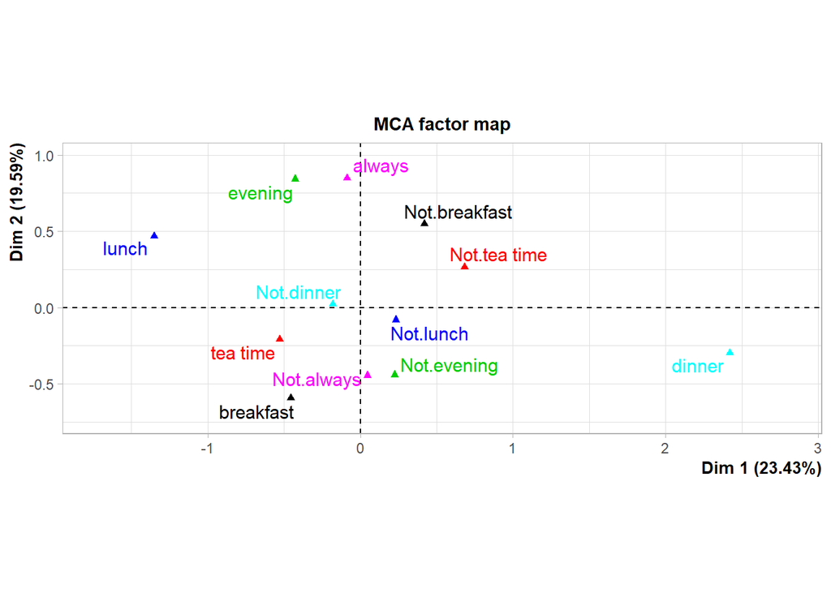

```r
plot(mca, invisible=c("ind"), habillage = "quali")
```

Dimension 1 to 4 explain more than 75% of the variabilities in the observations. Dim 1 is mostly explained by tea.time, lunch and dinner. Dim 2 is mostly explained by breakfast, evening and always. Dim 1 and 2 explain together about 43% of variabilities in the observations. From the biplot, we can see that there is a close relationship between Not.lunch, Not.evening and Not.always. dinner is the furthest. tea time is close to breakfast.